# IODS course project

# Logistic regression - analysis

### Tasks 1-3

```r
rawdata <- read.csv("Z:/IODS-project/data/alc.csv")
attach(rawdata)
glimpse(rawdata)
```

```
## Observations: 382
## Variables: 35
## $ school     <fctr> GP, GP, GP, GP, GP, GP, GP, GP, GP, GP, GP, GP, GP...
## $ sex        <fctr> F, F, F, F, F, M, M, F, M, M, F, F, M, M, M, F, F,...
## $ age        <int> 18, 17, 15, 15, 16, 16, 16, 17, 15, 15, 15, 15, 15,...
## $ address    <fctr> U, U, U, U, U, U, U, U, U, U, U, U, U, U, U, U, U,...
## $ famsize    <fctr> GT3, GT3, LE3, GT3, GT3, LE3, LE3, GT3, LE3, GT3, ...
## $ Pstatus    <fctr> A, T, T, T, T, T, T, A, A, T, T, T, T, T, A, T, T,...
## $ Medu       <int> 4, 1, 1, 4, 3, 4, 2, 4, 3, 3, 4, 2, 4, 4, 2, 4, 4, ...
## $ Fedu       <int> 4, 1, 1, 2, 3, 3, 2, 4, 2, 4, 4, 1, 4, 3, 2, 4, 4, ...
## $ Mjob       <fctr> at_home, at_home, at_home, health, other, services...
## $ Fjob       <fctr> teacher, other, other, services, other, other, oth...
## $ reason     <fctr> course, course, other, home, home, reputation, hom...
## $ nursery    <fctr> yes, no, yes, yes, yes, yes, yes, yes, yes, yes, y...
## $ internet   <fctr> no, yes, yes, yes, no, yes, yes, no, yes, yes, yes...
```

[output cut: 22 more lines]

From the glimpse() to the data we can see that is comprises 382 observations of 35 variables. The observations of the variables containt the attributes of the students, their socio-economic information and additional background information like the existence of internet access and the quality of their family relationships. The students’ alcohol usage is measured by daily and weekly consumption on a scale of 1-5, the average of the two, and a binary high consumption variable with an average consumption of over 2 as the limit.

Further information on all of the variables, except for the calulated ones, is available from the [source](https://archive.ics.uci.edu/ml/datasets/STUDENT+ALCOHOL+CONSUMPTION)

We now select four interesting variables for further analysis and make a hypothesis for each in relation to their effect on the students’ alcohol consumption.

Family relationships:  
H0: The quality of family relationships has no correlation to high alcohol consumption.  
H1: The quality of family relationships has a negative correlation to high alcohol consumption.

Absences:  
H0: The amount of absences has no correlation to high alcohol consumption.  
H1: The amount of absences has a positive correlation to high alcohol consumption.

Gender:  
H0: Gender has no correlation to high alcohol consumption.  
H1: Female students are less prone to high alcohol consumption than male students.

Extra-curriculars:  
H0: Engaging in extra-curricular activities has no correlation to high alcohol consumption.  
H1: Students with extra-curricular activities are less prone to high alcohol consumption than students with no extra-curricular activities.

### Task 4

We will proceed with examining the relationships between variables pertinent for each hypothesis to average alcohol consumption.

#### Family relationships

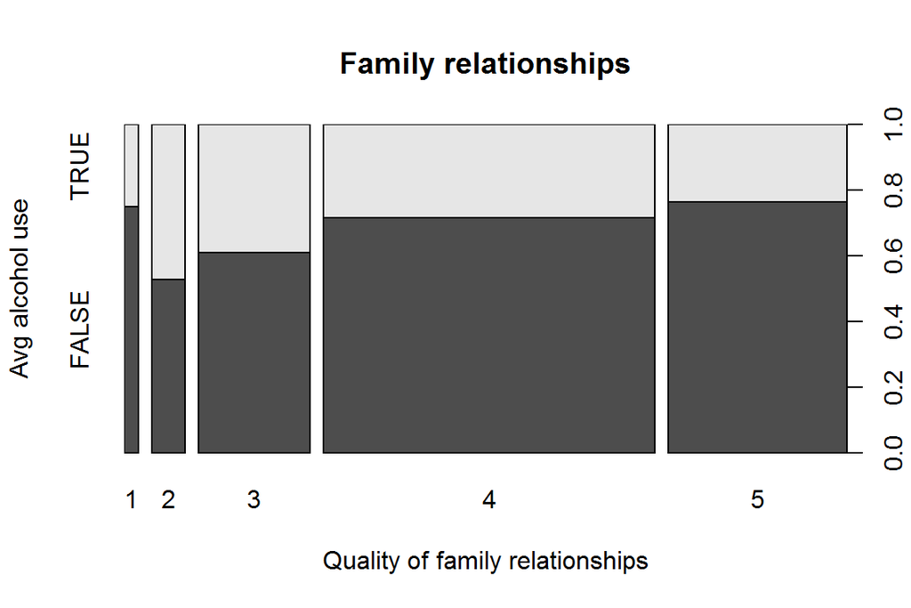

```r
plot(factor(high_use)~factor(famrel), xlab="Quality of family relationships", ylab="Avg alcohol use", main="Family relationships")
```

The correlation of the quality of family relationships to alcohol use does not seem large. The prevalence of high alcohol consumption is approximately the same in students with poor quality family relationships (=1) and students with high quality family relationships (=5). The number of students with the poorest quality family relationships appears to be the smallest in the dataset, while a large majority of students have evaluated their family relationships to be in the best two categories (4-5).

#### Absences

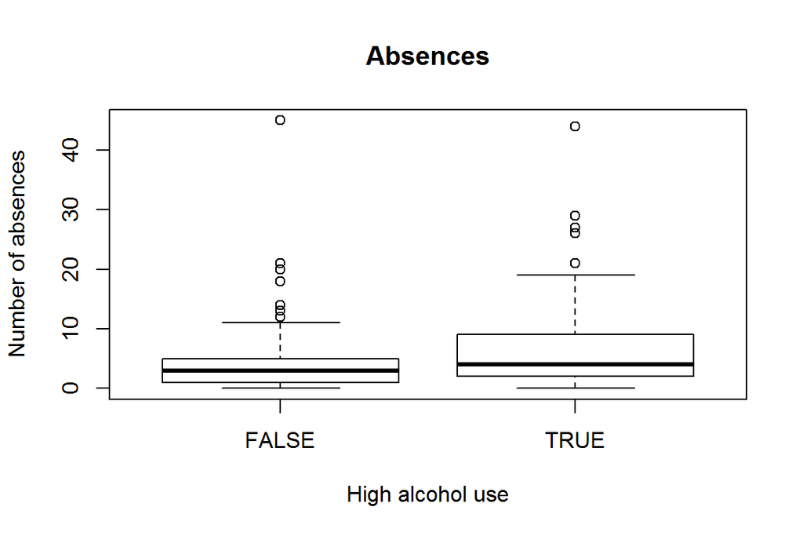

```r
plot(factor(high_use), absences, xlab="High alcohol use", ylab="Number of absences", main="Absences", type = "l")
```

From the boxplot we can see that students with more absences are more prone to high alcohol use, as the median, upper quartile and maximum (excluding outliers) for low alcohol use stay at just over 10 absences.

#### Gender

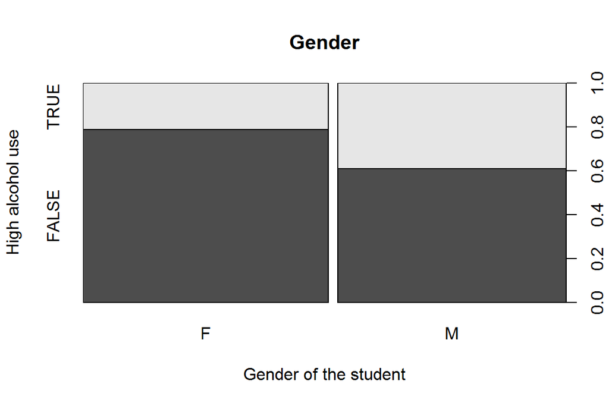

```r
plot(factor(high_use)~factor(sex), xlab="Gender of the student", ylab="High alcohol use", main="Gender")
```

The data shows that female students consume less alcohol than male students. Furthermore, the proportions of observations from females and males are quite even.

#### Extra-curriculars

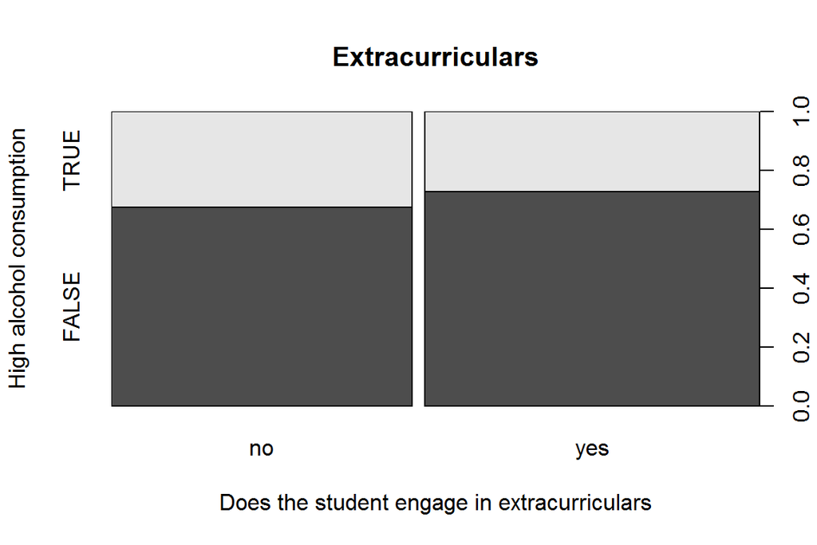

```r
plot(factor(high_use)~factor(activities), xlab="Does the student engage in extracurriculars", ylab="High alcohol consumption", main="Extracurriculars")
```

Engaging in extracurricular activities does not seem to correlate to a large degree with high alcohol consumption.

### Task 5

```r
m <- glm(high_use ~ famrel + absences + sex + activities, data = rawdata, family = "binomial")
summary(m)
```

```
##
## Call:
## glm(formula = high_use ~ famrel + absences + sex + activities,
##     family = "binomial", data = rawdata)
##
## Deviance Residuals:
##     Min       1Q   Median       3Q      Max
## -2.2742  -0.8201  -0.6138   1.0518   2.2184
##
## Coefficients:
##               Estimate Std. Error z value Pr(>|z|)
## (Intercept)   -0.58335    0.53792  -1.084   0.2782
## famrel        -0.28438    0.12826  -2.217   0.0266 *
## absences       0.09397    0.02260   4.157 3.22e-05 ***
## sexM           1.07615    0.24686   4.359 1.30e-05 ***
## activitiesyes -0.36623    0.24020  -1.525   0.1273
## ---
## Signif. codes:  0 '***' 0.001 '**' 0.01 '*' 0.05 '.' 0.1 ' ' 1
##
## (Dispersion parameter for binomial family taken to be 1)
##
##     Null deviance: 465.68  on 381  degrees of freedom
## Residual deviance: 422.52  on 377  degrees of freedom
## AIC: 432.52
##
## Number of Fisher Scoring iterations: 4
```

```r
OR <- coef(m) %>% exp
CI <- confint(m) %>% exp
cbind(OR, CI)
```

```
##                      OR     2.5 %   97.5 %
## (Intercept)   0.5580261 0.1916498 1.591650
## famrel        0.7524782 0.5839943 0.967432
## absences      1.0985270 1.0530061 1.150871
## sexM          2.9333705 1.8212403 4.803147
## activitiesyes 0.6933407 0.4316070 1.108576
```

### Task 6

```r
# predict() the probability of high_use
probabilities <- predict(m, type = "response")

# add the predicted probabilities to 'alc'
rawdata <- mutate(rawdata, probability = probabilities)

# use the probabilities to make a prediction of high_use
rawdata <- mutate(rawdata, prediction = probability > 0.5)
# tabulate the target variable versus the predictions
table(high_use = rawdata$high_use, prediction = rawdata$prediction)
```

```
##         prediction
## high_use FALSE TRUE
##    FALSE   250   18
##    TRUE     84   30
```

### Bonus: 10-fold cross-validation

```r
# define a loss function (average prediction error)
loss_func <- function(class, prob) {
  n_wrong <- abs(class - prob) > 0.5
  mean(n_wrong)
}

# compute the average number of wrong predictions in the (training) data
loss_func(class = rawdata$high_use, prob = rawdata$probability)
```

```
## [1] 0.2670157
```

```r
# K-fold cross-validation
library(boot)
cv <- cv.glm(data = rawdata, cost = loss_func, glmfit = m, K = 10)

# average number of wrong predictions in the cross validation
cv$delta[1]
```

```
## [1] 0.2722513
```

# Dimensionality reduction

## Task 1 - read, explore, and describe

Let’s first do some basic setup..

```r
setwd('Z:/IODS-project/data/')
human <- read.csv("human.txt", header = TRUE)
rownames(human) <- human$X
human <- subset(human, select = -X)
```

Then we’ll explore the dataset.

```r
str(human)
```

```
## 'data.frame':    155 obs. of  8 variables:
##  $ Edu2.FM  : num  1.007 0.997 0.983 0.989 0.969 ...
##  $ Labo.FM  : num  0.891 0.819 0.825 0.884 0.829 ...
##  $ Edu.Exp  : num  17.5 20.2 15.8 18.7 17.9 16.5 18.6 16.5 15.9 19.2 ...
##  $ Life.Exp : num  81.6 82.4 83 80.2 81.6 80.9 80.9 79.1 82 81.8 ...
##  $ GNI      : int  64992 42261 56431 44025 45435 43919 39568 52947 42155 32689 ...
##  $ Mat.Mor  : int  4 6 6 5 6 7 9 28 11 8 ...
##  $ Ado.Birth: num  7.8 12.1 1.9 5.1 6.2 3.8 8.2 31 14.5 25.3 ...
##  $ Parli.F  : num  39.6 30.5 28.5 38 36.9 36.9 19.9 19.4 28.2 31.4 ...
```

The dataset consists of the following data for each of the countries:

“Edu2.FM” = Ratio of females to each male with at least secondary education  
“Labo.FM” = Ratio of females to each male in the labour force  
“Edu.Exp” = Expected years of schooling  
“Life.Exp” = Life expectancy at birth  
“GNI” = Gross National Income per capita in US Dollars  
“Mat.Mor” = Maternal mortality rate  
“Ado.Birth” = Adolescent birth rate  
“Parli.F” = Percetange of female representatives in parliament

```r
dim(human)
```

```
## [1] 155   8
```

The dataset contanins 155 observations and 8 variables.

## Task 2 - Graphical overview and summaries

```r
cor_matrix<-cor(human) %>% round(digits=2)
cor_matrix
```

```
##           Edu2.FM Labo.FM Edu.Exp Life.Exp   GNI Mat.Mor Ado.Birth Parli.F
## Edu2.FM      1.00    0.01    0.59     0.58  0.43   -0.66     -0.53    0.08
## Labo.FM      0.01    1.00    0.05    -0.14 -0.02    0.24      0.12    0.25
## Edu.Exp      0.59    0.05    1.00     0.79  0.62   -0.74     -0.70    0.21
## Life.Exp     0.58   -0.14    0.79     1.00  0.63   -0.86     -0.73    0.17
## GNI          0.43   -0.02    0.62     0.63  1.00   -0.50     -0.56    0.09
## Mat.Mor     -0.66    0.24   -0.74    -0.86 -0.50    1.00      0.76   -0.09
## Ado.Birth   -0.53    0.12   -0.70    -0.73 -0.56    0.76      1.00   -0.07
## Parli.F      0.08    0.25    0.21     0.17  0.09   -0.09     -0.07    1.00
```

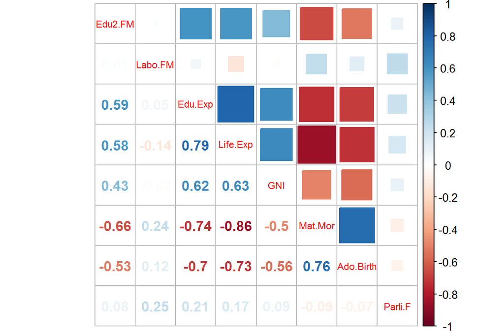

```r
corrplot.mixed(cor_matrix, upper="square", tl.cex = 0.7)
```

From the correlation plot we can see that the percentage of female representatives in parliament and the ratio of females to males in the labour force do not correlate strongly with any of the other variables ($\mathit{r} \le \pm .25$). Their strongest correlation is with each other.

The strongest correlation coefficients ($\mathit{r} \ge\pm.7$) can be found between

- Maternal mortality rate and life expectancy ($\mathit{r}=-.86$)
- Expected years of schooling and life expectancy ($\mathit{r}=.79$)
- Maternal mortality rate and adolescent birth rate ($\mathit{r}=.76$)
- Expected years of schooling and maternal mortality rate ($\mathit{r}=-.74$)
- Adolescent birth rate and life expectancy ($\mathit{r}=-.73$)
- Expected years of schooling and adolescent birth rate ($\mathit{r}=-.7$)

```r
summary(human)
```

```
##     Edu2.FM          Labo.FM          Edu.Exp         Life.Exp
##  Min.   :0.1717   Min.   :0.1857   Min.   : 5.40   Min.   :49.00
##  1st Qu.:0.7264   1st Qu.:0.5984   1st Qu.:11.25   1st Qu.:66.30
##  Median :0.9375   Median :0.7535   Median :13.50   Median :74.20
##  Mean   :0.8529   Mean   :0.7074   Mean   :13.18   Mean   :71.65
##  3rd Qu.:0.9968   3rd Qu.:0.8535   3rd Qu.:15.20   3rd Qu.:77.25
##  Max.   :1.4967   Max.   :1.0380   Max.   :20.20   Max.   :83.50
##       GNI            Mat.Mor         Ado.Birth         Parli.F
##  Min.   :   581   Min.   :   1.0   Min.   :  0.60   Min.   : 0.00
##  1st Qu.:  4198   1st Qu.:  11.5   1st Qu.: 12.65   1st Qu.:12.40
##  Median : 12040   Median :  49.0   Median : 33.60   Median :19.30
##  Mean   : 17628   Mean   : 149.1   Mean   : 47.16   Mean   :20.91
##  3rd Qu.: 24512   3rd Qu.: 190.0   3rd Qu.: 71.95   3rd Qu.:27.95
##  Max.   :123124   Max.   :1100.0   Max.   :204.80   Max.   :57.50
```

The distributions of the variables conform quite well with normal distribution. GNI and maternal mortality rate seem a bit suspect, as the former has a maximum well beyond the first three first quartiles, and the latter is skewed towards the third quartile.

## Task 3 - PCA

```r
pca_human <- prcomp(human)
summary(pca_human)
```

```
## Importance of components%s:
##                              PC1      PC2   PC3   PC4   PC5   PC6    PC7
## Standard deviation     1.854e+04 185.5219 25.19 11.45 3.766 1.566 0.1912
## Proportion of Variance 9.999e-01   0.0001  0.00  0.00 0.000 0.000 0.0000
## Cumulative Proportion  9.999e-01   1.0000  1.00  1.00 1.000 1.000 1.0000
##                           PC8
## Standard deviation     0.1591
## Proportion of Variance 0.0000
## Cumulative Proportion  1.0000
```

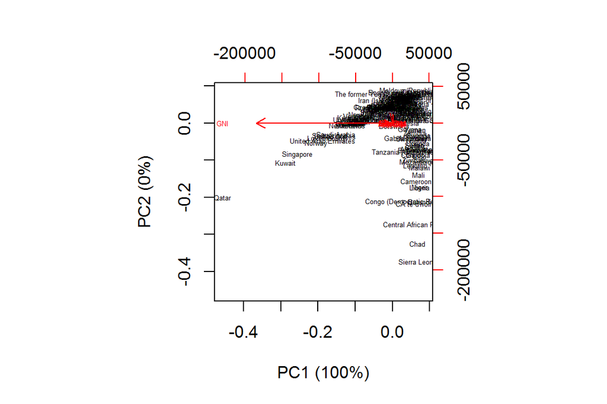

```r
prelabel <- round(100*summary(pca_human)$importance[2, ], digits = 1)
label <- paste0(names(prelabel), " (", prelabel, "%)")
biplot(pca_human, choices = 1:2, cex = 0.4, xlab = label[1], ylab = label[2])
```

## Task 4 - Standardisation and new PCA

```r
human_std <- scale(human)
pca_human_std <- prcomp(human_std)
summary(pca_human_std)
```

```
## Importance of components%s:
##                           PC1    PC2     PC3     PC4     PC5     PC6
## Standard deviation     2.0708 1.1397 0.87505 0.77886 0.66196 0.53631
## Proportion of Variance 0.5361 0.1624 0.09571 0.07583 0.05477 0.03595
## Cumulative Proportion  0.5361 0.6984 0.79413 0.86996 0.92473 0.96069
##                            PC7     PC8
## Standard deviation     0.45900 0.32224
## Proportion of Variance 0.02634 0.01298
## Cumulative Proportion  0.98702 1.00000
```

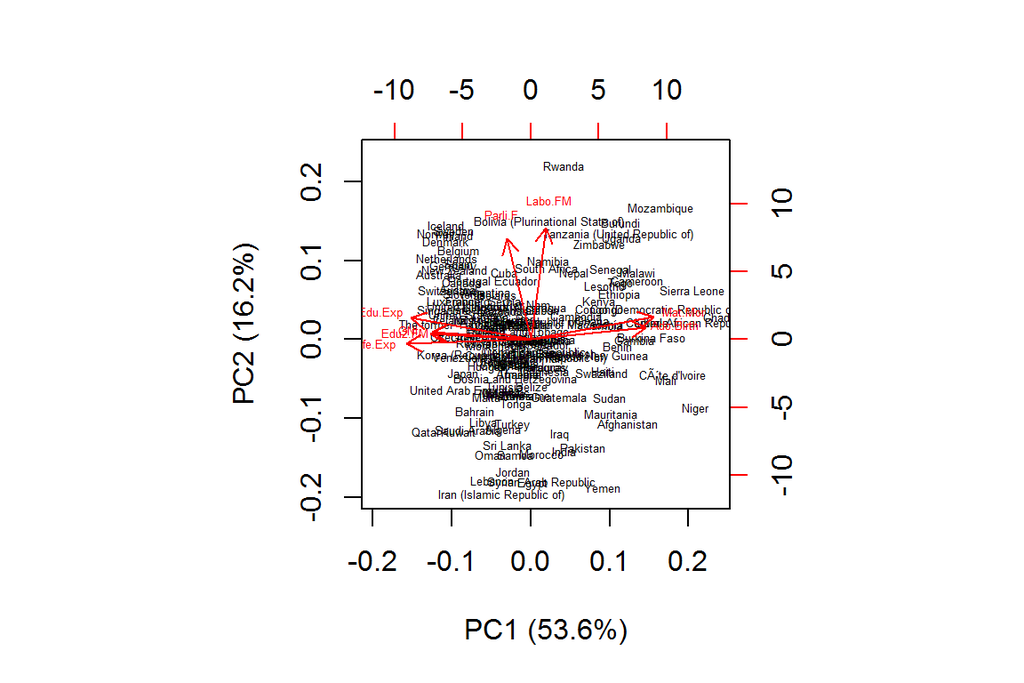

```r
prelabel_std <- round(100*summary(pca_human_std)$importance[2, ], digits = 1)
label_std <- paste0(names(prelabel_std), " (", prelabel_std, "%)")
biplot(pca_human_std, choices = 1:2, cex = 0.4, xlab = label_std[1], ylab = label_std[2])
```

The unstandardised plot does not offer substantial information in addition to the large variance in GNI, and the GNI outliers that cause the unreadability of the plot. From the GNI we can deduce that oil-rich countries are leading the pack with Singapore and Luxembourg. The effect of the GNI dominance in the first principal component (PC1) makes the second and subsequence principal components undiscernible.

Standardising the variables make the principal component graph more readable by diminishing the dominance of GNI.

From the standardised biplot we can find three dimensions of interconnected variables: GNI, life expectancy, expected years of schooling and the ratio of females to males with at least secondary education are grouped together; the ratio of females to males in the labour force are grouped together, and maternal mortality rate and adolescent birth rate are grouped together. These groupings correspond to the correlation coefficients analysed earlier.

## Task 5 - Interpretations

When analysed through principal component 1, the first grouping is a polar opposite to the third grouping, with both adolescent births and maternal mortality decreasing when GNI, life expectancy, and education levels increase.

## Task 6 - MCA of tea dataset

```r
tea <- read.table("http://factominer.free.fr/book/tea.csv",header=TRUE,sep=";")
```

```r
str(tea)
```

```
## 'data.frame':    300 obs. of  36 variables:
##  $ breakfast        : Factor w/ 2 levels "breakfast","not.breakfast": 1 1 2 2 1 2 1 2 1 1 ...
##  $ afternoon.tea    : Factor w/ 2 levels "afternoon.tea",..: 2 2 1 2 2 2 1 1 1 2 ...
##  $ evening          : Factor w/ 2 levels "evening","not.evening": 2 2 1 2 1 2 2 1 2 1 ...
##  $ after.lunch      : Factor w/ 2 levels "after.lunch",..: 2 2 2 2 2 2 2 2 2 2 ...
##  $ after.dinner     : Factor w/ 2 levels "after.dinner",..: 2 2 1 1 2 1 2 2 2 2 ...
##  $ anytime          : Factor w/ 2 levels "anytime","not.anytime": 2 2 2 2 1 2 2 2 2 2 ...
##  $ home             : Factor w/ 2 levels "home","not.home": 1 1 1 1 1 1 1 1 1 1 ...
##  $ work             : Factor w/ 2 levels "not.work","work": 1 1 2 1 1 1 1 1 1 1 ...
##  $ tearoom          : Factor w/ 2 levels "not.tearoom",..: 1 1 1 1 1 1 1 1 1 2 ...
##  $ friends          : Factor w/ 2 levels "friends","not.friends": 2 2 1 2 2 2 1 2 2 2 ...
##  $ restaurant       : Factor w/ 2 levels "not.restaurant",..: 1 1 2 1 1 1 1 1 1 1 ...
##  $ pub              : Factor w/ 2 levels "not.pub","pub": 1 1 1 1 1 1 1 1 1 1 ...
##  $ variety          : Factor w/ 3 levels "black","flavoured",..: 1 1 2 2 2 2 2 1 2 1 ...
##  $ how              : Factor w/ 4 levels "lemon","milk",..: 3 2 3 3 3 3 3 2 2 3 ...
```

[output cut: 22 more lines]

We can now see that all of the variables except age are factors with 2-7 levels.

```r
dim(tea)
```

```
## [1] 300  36
```

There are 300 observations of 36 variables.

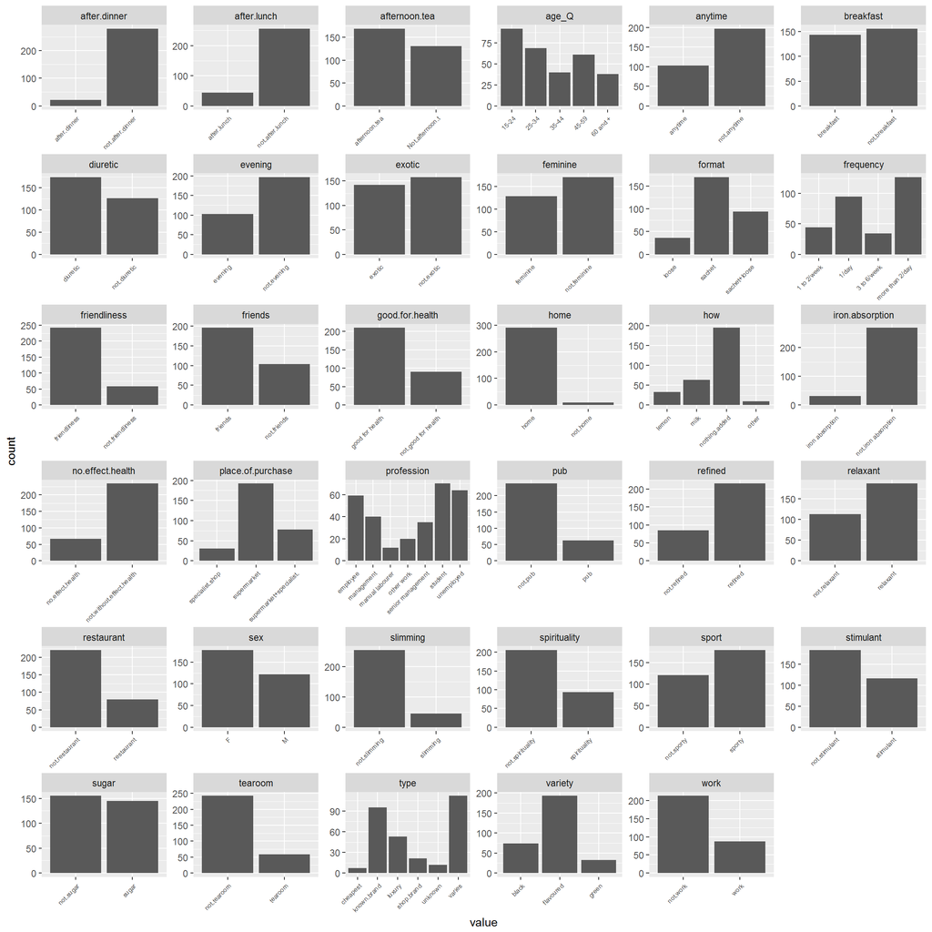

```r
tea <- subset(tea, select = -age)
gather(tea) %>% ggplot(aes(value)) + facet_wrap("key", scales = "free") + geom_bar() + theme(axis.text.x = element_text(angle = 45, hjust = 1, size = 6))
```

The graphical presentation of the variables shows that there are some categories with very low frequencies, which may distort the analysis. Hence the following variables should be dropped before engaging in further analysis:

- after.dinner
- after.lunch
- home
- iron.absorption
- slimming

```r
tea <- subset(tea, select = -c(after.dinner, after.lunch, home, iron.absorption, slimming))
mca <- MCA(tea, graph = FALSE)
summary(mca)
```

```
##
## Call:
## MCA(X = tea, graph = FALSE)
##
##
## Eigenvalues
##                        Dim.1   Dim.2   Dim.3   Dim.4   Dim.5   Dim.6
## Variance               0.101   0.094   0.078   0.072   0.064   0.061
## % of var.              6.205   5.779   4.749   4.392   3.898   3.736
## Cumulative % of var.   6.205  11.984  16.733  21.125  25.024  28.760
##                        Dim.7   Dim.8   Dim.9  Dim.10  Dim.11  Dim.12
## Variance               0.056   0.053   0.048   0.047   0.046   0.044
## % of var.              3.444   3.228   2.947   2.889   2.816   2.722
## Cumulative % of var.  32.204  35.432  38.379  41.269  44.084  46.806
##                       Dim.13  Dim.14  Dim.15  Dim.16  Dim.17  Dim.18
## Variance               0.041   0.041   0.038   0.037   0.036   0.036
## % of var.              2.517   2.501   2.344   2.279   2.230   2.176
## Cumulative % of var.  49.323  51.824  54.168  56.447  58.677  60.852
##                       Dim.19  Dim.20  Dim.21  Dim.22  Dim.23  Dim.24
## Variance               0.035   0.033   0.033   0.032   0.031   0.029
## % of var.              2.138   2.023   1.993   1.957   1.885   1.759
## Cumulative % of var.  62.990  65.013  67.006  68.963  70.848  72.607
##                       Dim.25  Dim.26  Dim.27  Dim.28  Dim.29  Dim.30
## Variance               0.028   0.027   0.026   0.025   0.025   0.025
## % of var.              1.702   1.656   1.599   1.558   1.532   1.508
## Cumulative % of var.  74.309  75.966  77.564  79.122  80.654  82.162
##                       Dim.31  Dim.32  Dim.33  Dim.34  Dim.35  Dim.36
## Variance               0.023   0.022   0.021   0.020   0.019   0.018
## % of var.              1.405   1.361   1.265   1.229   1.162   1.123
## Cumulative % of var.  83.567  84.928  86.193  87.422  88.584  89.707
##                       Dim.37  Dim.38  Dim.39  Dim.40  Dim.41  Dim.42
## Variance               0.018   0.017   0.016   0.015   0.015   0.014
## % of var.              1.074   1.048   0.991   0.937   0.889   0.871
## Cumulative % of var.  90.781  91.829  92.820  93.757  94.646  95.517
##                       Dim.43  Dim.44  Dim.45  Dim.46  Dim.47  Dim.48
## Variance               0.013   0.012   0.012   0.012   0.010   0.008
## % of var.              0.789   0.749   0.713   0.705   0.593   0.498
## Cumulative % of var.  96.306  97.055  97.767  98.472  99.066  99.564
##                       Dim.49
## Variance               0.007
```

[output cut: 48 more lines]

```
## not.work         2.813 | -0.137  0.575  0.046 -3.714 |
## work            -2.813 |  0.336  1.408  0.046  3.714 |
##
## Categorical variables (eta2)
##                   Dim.1 Dim.2 Dim.3
## breakfast       | 0.016 0.000 0.000 |
## afternoon.tea   | 0.222 0.002 0.014 |
## evening         | 0.032 0.083 0.064 |
## anytime         | 0.051 0.048 0.021 |
## work            | 0.075 0.026 0.046 |
## tearoom         | 0.374 0.008 0.011 |
## friends         | 0.182 0.073 0.020 |
## restaurant      | 0.154 0.011 0.027 |
## pub             | 0.146 0.066 0.000 |
## variety         | 0.059 0.270 0.015 |
```

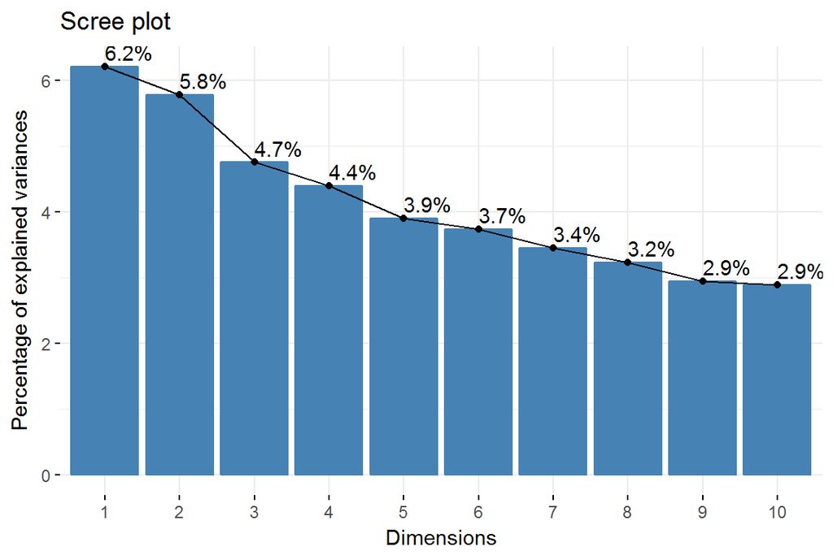

```r
fviz_screeplot(mca, addlabels = TRUE)
```

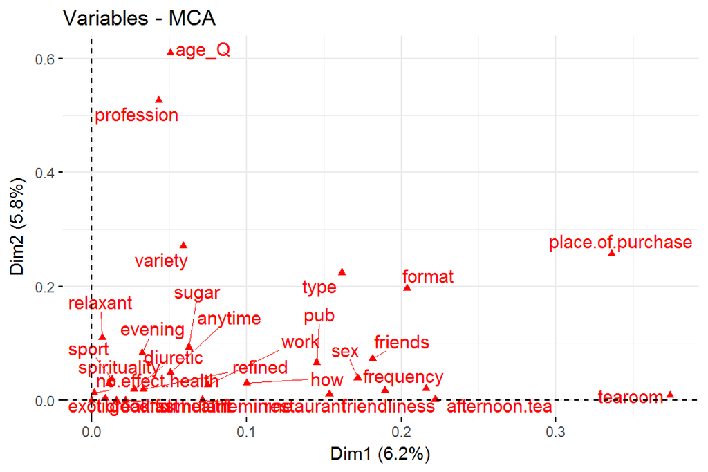

```r
fviz_mca_var(mca, choice = "mca.cor",
            repel = TRUE, # Avoid text overlapping (slow)
            ggtheme = theme_minimal())
```

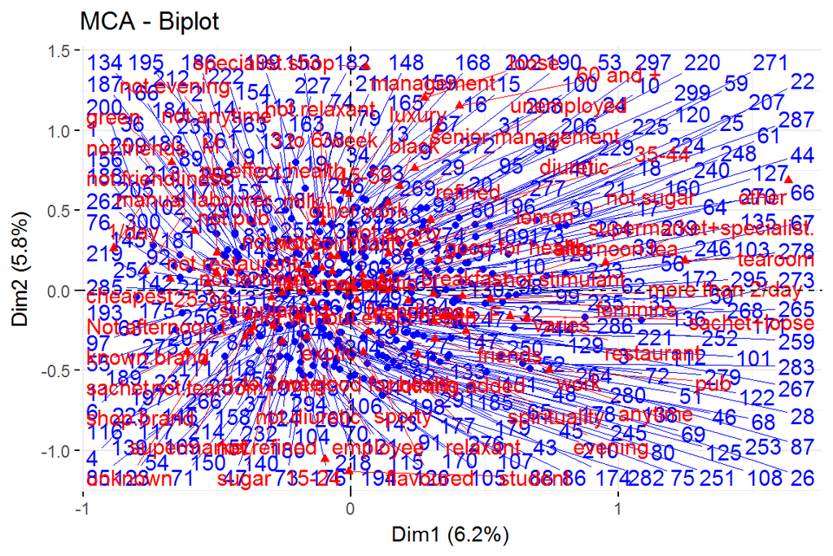

```r
fviz_mca_biplot(mca, repel = TRUE, ggtheme = theme_minimal())
```

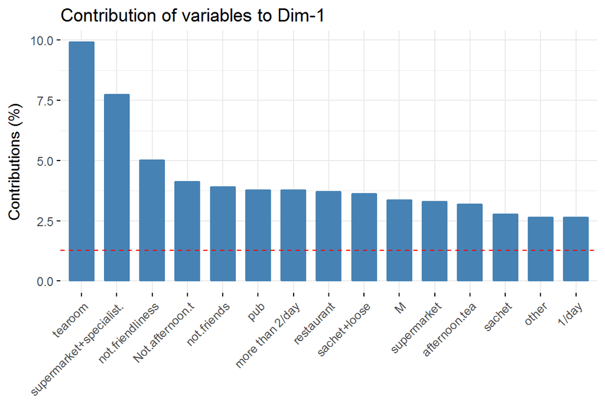

```r
# Contributions of rows to dimension 1
fviz_contrib(mca, choice = "var", axes = 1, top = 15)
```

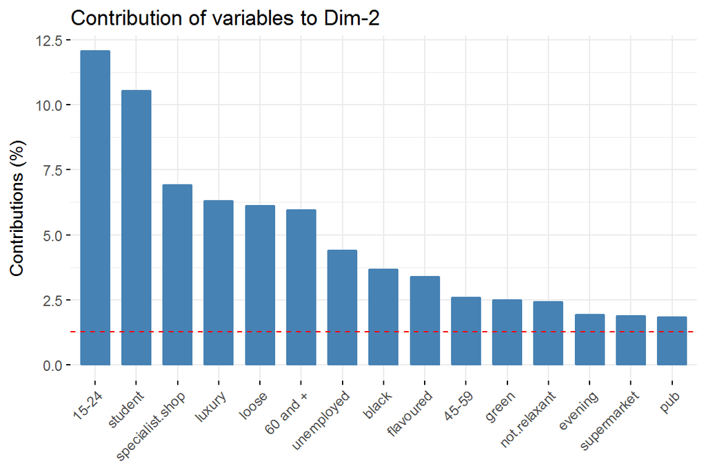

```r
# Contributions of rows to dimension 2
fviz_contrib(mca, choice = "var", axes = 2, top = 15)
```

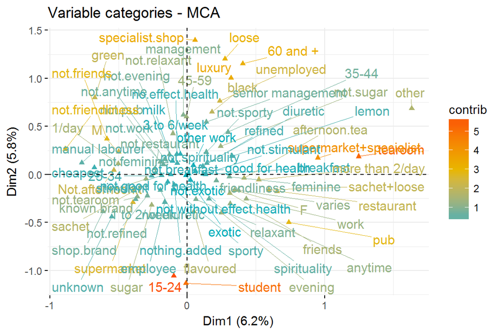

```r
#biplot(mca, choices = 1:2, cex = 0.6)
fviz_mca_var(mca, col.var = "contrib",
             gradient.cols = c("#00AFBB", "#E7B800", "#FC4E07"),
             repel = TRUE, # avoid text overlapping (slow)
             ggtheme = theme_minimal()
             )
```

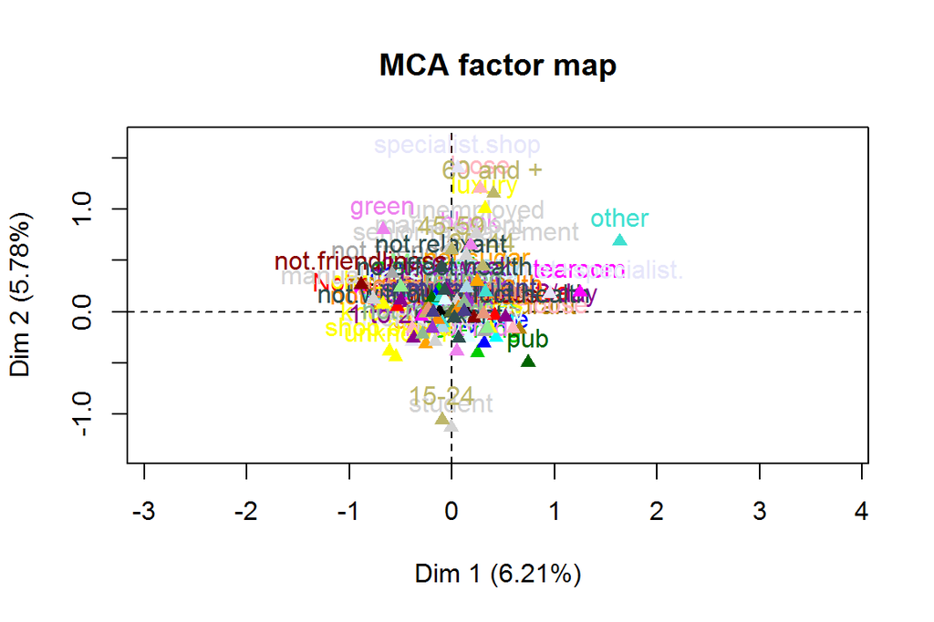

```r
plot(mca, habillage = "quali", invisible=c("ind"))
```